# Milestone project

MJM Beuken

12 juni 2018

For the capstone project I have to create an application that predicts the next word in a sentence. To create this application, I will use natural language processing, namely: N-grams to evaluate the statistical probability that the next word appears when one looks to the prior word or multiple words. The data we will use will be a variety of large bodies (corpus) of text documents, such as: blog data, news data and twitter data. In this report, I will go into the details of the Corpora and show some descriptive statistics to research possibilities for modeling the data.

## Given Data

For this project, some files were provided. These files contained twitter messages, news articles and blog entries in four different languages. I will use only the US English data to crate the application where I already spoke of.

```r
## Reading data

setwd("./final/en_US")
US.blog <- readLines("en_US.blogs.txt",skipNul = T, warn = T)
US.news <- readLines("en_US.news.txt",skipNul = T, warn = T)
US.twitter <- readLines("en_US.twitter.txt",skipNul = T, warn = T)
```

```r
## Do the analysis of the data by counting words, lines en line length per dataset: blogs, news and twitter.
#Get line counts
bloglines <- length(US.blog)
newslines <- length(US.news)
twitterlines <- length(US.twitter)

#Get max line length
blog.char.cnt <- lapply(US.blog, nchar)
blog.max.chars <- blog.char.cnt[[which.max(blog.char.cnt)]]

news.char.cnt <- lapply(US.news, nchar)
news.max.chars <- news.char.cnt[[which.max(news.char.cnt)]]

twitter.char.cnt <- lapply(US.twitter, nchar)
twitter.max.chars <- twitter.char.cnt[[which.max(twitter.char.cnt)]]

#Get word counts (based on spaces)
blog.words <- sum( sapply(gregexpr("\\S+", US.blog), length ) )
news.words <- sum( sapply(gregexpr("\\S+", US.news), length ) )
twitter.words <- sum( sapply(gregexpr("\\S+", US.twitter), length ) )
```

Summary of corpus statistics

```r
stats <- data.frame( "Files" = c("Blogs", "News", "Twitter"),
                            "Line count" = c(bloglines, newslines, twitterlines),
                            "Longest Line" = c(blog.max.chars, news.max.chars, twitter.max.chars),
                            "Word count" = c(blog.words, news.words, twitter.words))
print(stats)
```

```
##     Files Line.count Longest.Line Word.count
## 1   Blogs     899288        40835   37334441
## 2    News      77259         5760    2643972
## 3 Twitter    2360148          213   30373832
```

## Sampling

Because of the large size of these data, processing the data on a local computer takes a lot of time. To improve calculation time the data is sampled. For each corpus, I chose to randomly sample 5% of the data and combined them into a single file.

```r
set.seed(1234)
samplesize.blogs <- round(0.05*length(US.blog))
samplesize.news <- round(0.05*length(US.news))
samplesize.twitter <- round(0.05*length(US.twitter))


sample.blogs   <- sample(US.blog, samplesize.blogs, replace = T)
sample.news    <- sample(US.news, samplesize.news, replace = T)
sample.twitter <- sample(US.twitter, samplesize.twitter, replace = T)

sample <- c(sample.blogs, sample.news, sample.twitter)
```

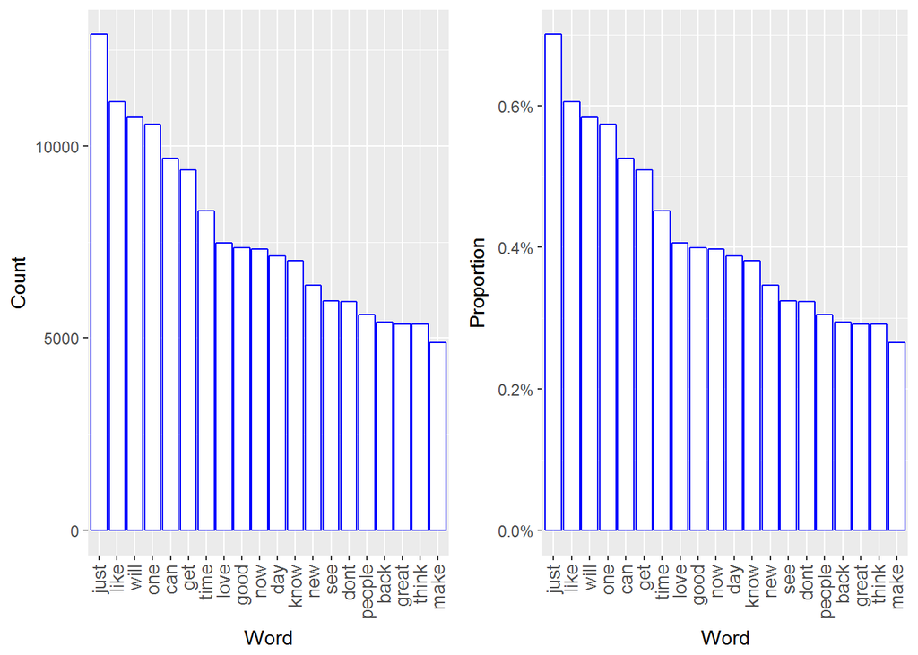

```r
## creating a corpus
vectorsample <- VectorSource(sample)
vectorsample <- Corpus(vectorsample)

## Remove URL's

removeURL <- gsub("http[^[:space:]]*", "", vectorsample)


# Remove anything other than English letters or space

removeNumPunct <- gsub("[^[:alpha:][:space:]]*", "", removeURL)
removePunct <- removePunctuation(removeNumPunct)

## All lower case

cleansample <- tolower(removePunct)


## remove profanity
## profanity list
setwd("./final/en_US")
Profanitylist <- read.csv("./Profanitylist.csv", header=FALSE)

Profanitylist <- as.character(Profanitylist$V1)
Profanitylist <- c(Profanitylist)

##Then one can apply custom words to text file.

cleansample <- VectorSource(cleansample)
cleansample <- VCorpus(cleansample)
cleansample <- tm_map(cleansample, content_transformer(tolower))
cleansample <- tm_map(cleansample, removeWords, Profanitylist)
cleansample <- tm_map(cleansample, removeWords, c("vested", "interests"))
cleansample <- tm_map(cleansample, stripWhitespace)

cleansample.ns <- tm_map(cleansample, removeWords, stopwords('english'))

## create doc term matrix
dtm <- DocumentTermMatrix(cleansample.ns)


## converting text to matrix and Need to remove sparse elements, otherwise recource of memory will be to demanding
dtm.ST <- removeSparseTerms(dtm, 0.9999)
dtm.matrix <- as.matrix(dtm.ST)


wordcount <- colSums(dtm.matrix)
toptwenty <- head(sort(wordcount, decreasing=TRUE), 20)


dfplot <- as.data.frame(melt(toptwenty))
dfplot$word <- dimnames(dfplot)[[1]]
dfplot$word <- factor(dfplot$word,
                      levels=dfplot$word[order(dfplot$value,
                                               decreasing=TRUE)])

fig <- ggplot(dfplot, aes(x=word, y=value)) + geom_bar(stat="identity", color = "blue", fill = "white") + xlab("Word") + ylab("Count") +
        theme(axis.text.x = element_text(angle = 90, size = 10, hjust = 1, vjust = 0.4))

## proportion
count <- sum(sort(wordcount, decreasing = T))
prop <- toptwenty/count
fig.prop <- ggplot(dfplot, aes(x = word, y = prop)) +
        geom_bar(stat="identity", color = "blue", fill = "white") + xlab("Word")+ ylab("Proportion") +
        theme(axis.text.x = element_text(angle = 90, size = 10, hjust = 1, vjust = 0.4)) +
        scale_y_continuous(labels = percent)

## plot of both bar charts.
ggarrange(fig, fig.prop,
          ncol = 2)
```

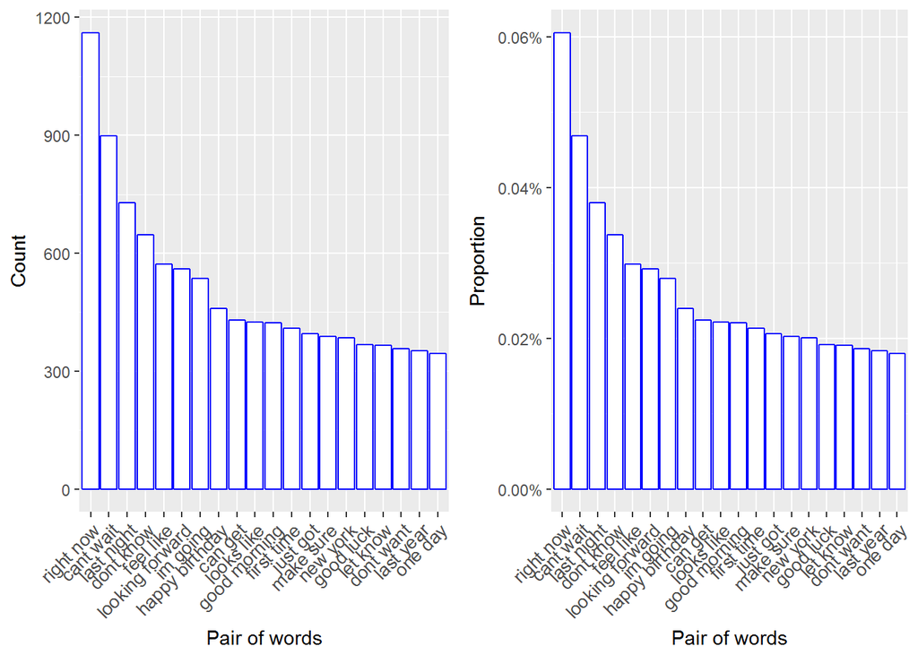

```r
## Trying to get a picture of the pair of words that are most common.
twogram <-
        function(x)
                unlist(lapply(ngrams(words(x), 2), paste, collapse = " "), use.names = FALSE)


dtm2 <- DocumentTermMatrix(cleansample.ns,
                           control=list(tokenize=twogram))

# Need to remove sparse elements, otherwise recource of memory will be to demanding
dtm2.ST <- removeSparseTerms(dtm2, 0.9999)
dtm2.matrix <- as.matrix(dtm2.ST)

wordcount2 <- colSums(dtm2.matrix)
toptwenty2 <- head(sort(wordcount2, decreasing=TRUE), 20)

dfplot2 <- as.data.frame(melt(toptwenty2))
dfplot2$word <- dimnames(dfplot2)[[1]]
dfplot2$word <- factor(dfplot2$word,
                      levels=dfplot2$word[order(dfplot2$value,
                                               decreasing=TRUE)])

fig2 <- ggplot(dfplot2, aes(x=word, y=value)) + geom_bar(stat="identity", color = "blue", fill = "white") + xlab("Pair of words")+ ylab("Count") +
        theme(axis.text.x = element_text(angle = 45, size = 10, hjust = 1))


## proportion of words

count2 <- sum(sort(wordcount2, decreasing = T))
prop2 <- toptwenty2/count2
fig.prop2 <- ggplot(dfplot2, aes(x = word, y = prop2)) +
        geom_bar(stat="identity", color = "blue", fill = "white") + xlab("Pair of words")+ ylab("Proportion") +
        theme(axis.text.x = element_text(angle = 45, size = 10, hjust = 1)) +
        scale_y_continuous(labels = percent)

## plot of both bar charts.
ggarrange(fig2, fig.prop2,
          ncol = 2)
```

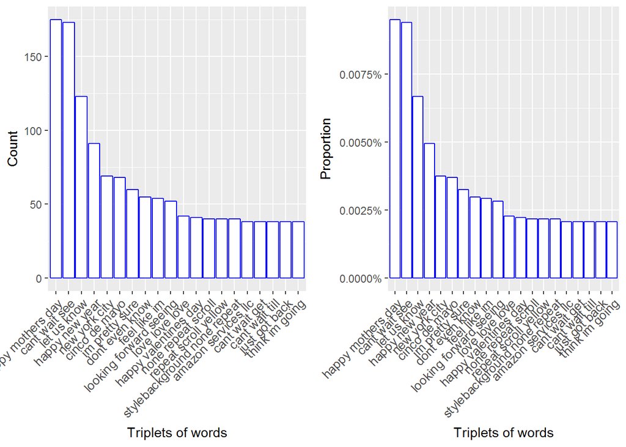

```r
## Trying to get a picture of the triplets of words that are most common.
threegram <-
        function(x)
                unlist(lapply(ngrams(words(x), 3), paste, collapse = " "), use.names = FALSE)

dtm3 <- DocumentTermMatrix(cleansample.ns,
                           control=list(tokenize=threegram))

dtm3.matrix <- as.matrix(dtm3)

wordcount3 <- colSums(dtm3.matrix)
toptwenty3 <- head(sort(wordcount3, decreasing=TRUE), 20)

dfplot3 <- as.data.frame(melt(toptwenty3))
dfplot3$word <- dimnames(dfplot3)[[1]]
dfplot3$word <- factor(dfplot3$word,
                      levels=dfplot3$word[order(dfplot3$value,
                                               decreasing=TRUE)])

fig3 <- ggplot(dfplot3, aes(x=word, y=value)) + geom_bar(stat="identity", color = "blue", fill = "white") + xlab("Triplets of words")+ ylab("Count") +
        theme(axis.text.x = element_text(angle = 45, size = 10, hjust = 1))



## plot with proportion on y-axis

count3 <- sum(sort(wordcount3, decreasing = T))
prop3 <- toptwenty3/count
fig.prop3 <- ggplot(dfplot3, aes(x = word, y = prop3)) +
        geom_bar(stat="identity", color = "blue", fill = "white") + xlab("Triplets of words")+ ylab("Proportion") +
                theme(axis.text.x = element_text(angle = 45, size = 10, hjust = 1)) +
                        scale_y_continuous(labels = percent)
## plot of both bar charts.
ggarrange(fig3, fig.prop3,
          ncol = 2)
```

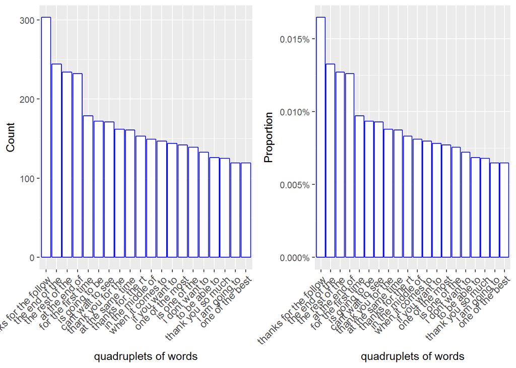

```r
## Trying to get a picture of the quadriples of words that are most common.
fourgram <-
        function(x)
                unlist(lapply(ngrams(words(x), 4), paste, collapse = " "), use.names = FALSE)

dtm4 <- DocumentTermMatrix(cleansample,
                           control=list(tokenize=fourgram))

dtm4.matrix <- as.matrix(dtm4)

wordcount4 <- colSums(dtm4.matrix)
toptwenty4 <- head(sort(wordcount4, decreasing=TRUE), 20)

dfplot4 <- as.data.frame(melt(toptwenty4))
dfplot4$word <- dimnames(dfplot4)[[1]]
dfplot4$word <- factor(dfplot4$word,
                       levels=dfplot4$word[order(dfplot4$value,
                                                 decreasing=TRUE)])

fig4 <- ggplot(dfplot4, aes(x=word, y=value)) + geom_bar(stat="identity", color = "blue", fill = "white") + xlab("quadruplets of words")+ ylab("Count") +
        theme(axis.text.x = element_text(angle = 45, size = 10, hjust = 1))



## plot with proportion on y-axis

count4 <- sum(sort(wordcount4, decreasing = T))
prop4 <- toptwenty4/count
fig.prop4 <- ggplot(dfplot4, aes(x = word, y = prop4)) +
        geom_bar(stat="identity", color = "blue", fill = "white") + xlab("quadruplets of words")+ ylab("Proportion") +
        theme(axis.text.x = element_text(angle = 45, size = 10, hjust = 1)) +
        scale_y_continuous(labels = percent)

## plot of both bar charts.
ggarrange(fig4, fig.prop4,
          ncol = 2)
```

# And now …

Based on the sampled data analyzed above I will create a statistical model (based on N-grams/Markov Models) to predict the next word. The model created will be evaluated to make sure that a good balance between accuracy and speed is considered. This iterative process will may require other techniques and new data sources.